# Combined_Stats2_Project1_AC_AP_GL

Adam Canton, Anish Patel & Grace Lang

6/7/2020

Kaggle link for data reference: https://www.kaggle.com/kumarajarshi/life-expectancy-who

#Column definitions: Adult.mortality: Adult Mortality Rates of both sexes (probability of dying between 15 and 60 years per 1000 population) Infant.death: Number of Infant Deaths per 1000 population Alcohol: Alcohol, recorded per capita (15+) consumption (in litres of pure alcohol) percentage expenditure: Expenditure on health as a percentage of Gross Domestic Product per capita(%) Hepatitis B: Hepatitis B (HepB) immunization coverage among 1-year-olds (%) Measles - number of reported cases per 1000 population BMI: Average Body Mass Index of entire population Under-five-deaths: Number of under-five deaths per 1000 population Polio: Polio (Pol3) immunization coverage among 1-year-olds (%) Total expenditure: General government expenditure on health as a percentage of total government expenditure (%) Diphtheria: Diphtheria tetanus toxoid and pertussis (DTP3) immunization coverage among 1-year-olds (%) HIV/AIDS: Deaths per 1 000 live births HIV/AIDS (0-4 years) GDP: Gross Domestic Product per capita (in USD) Population: Population of the country thinness: Prevalence of thinness among children and adolescents for Age 10 to 19 (% ) Thinness 5-9: Prevalence of thinness among children for Age 5 to 9(%) income composition: Human Development Index in terms of income composition of resources (index ranging from 0 to 1) Schooling: Number of years of Schooling(years)

# Fixing NA’s in GDP

```r
Life14$GDP[159] = 2520.2027
Life14$GDP[11] = 29436.13
Life14$GDP[20] = 3081.23
Life14$GDP[28] = 1559.38
Life14$GDP[39] = 6208.58
Life14$GDP[44] = 19771.65
Life14$GDP[45] = 1568.63
Life14$GDP[46] = 352.82
Life14$GDP[51] = 3378.68
Life14$GDP[54] = 1209.68
Life14$GDP[61] = 607.21
Life14$GDP[77] = 5608.62
Life14$GDP[89] = 1279.64
Life14$GDP[90] = 1998.49
Life14$GDP[95] = 6466.52
Life14$GDP[107] = 2971.73
Life14$GDP[131] = 27802.96
Life14$GDP[132] = 2674.35
Life14$GDP[136] = 8743.89
Life14$GDP[137] = 6684.67
Life14$GDP[146] = 18671.59
Life14$GDP[162] = 5487.92
Life14$GDP[173] = 47614.61
Life14$GDP[174] = 1000.00
Life14$GDP[175] = 55025.13
Life14$GDP[179] = 16053.24
Life14$GDP[180] = 2030.31
Life14$GDP[181] = 1674.28
```

# Fixing Population NA’s

```r
Life14$Population[159] = 18715672
Life14$Population[11] = 370633
Life14$Population[20] = 10710000
Life14$Population[28] = 22650000
Life14$Population[39] = 5244359
Life14$Population[44] = 10510000
Life14$Population[45] = 25500000
Life14$Population[46] = 10780263
Life14$Population[51] = 90420000
Life14$Population[54] = 5580000
Life14$Population[61] = 2024000
Life14$Population[77] = 77470000
Life14$Population[89] = 5836000
Life14$Population[90] = 6640000
Life14$Population[95] = 6362000
Life14$Population[107] = 107446
Life14$Population[131] = 50750000
Life14$Population[132] = 3556000
Life14$Population[136] = 178296
Life14$Population[137] = 108861
Life14$Population[146] = 5420000
Life14$Population[162] = 2070000
Life14$Population[173] = 64350000
Life14$Population[174] = 49960000
Life14$Population[175] = 318400000
Life14$Population[179] = 30050000
Life14$Population[180] = 91710000
Life14$Population[181] = 25820000
Life14$Population[130] = 2459000
Life14$Population[145] = 5470000
Life14$Population[172] = 9214000
Life14$Population[88] = 3691000
Life14$Population[12] = 1336000
Life14$Population[140] = 30920000
Life14$Population[14] = 284825
Life14$Population[5] = 92562
Life14$Population[66] = 108902
Life14$Population[116] = 4510000
Life14$Population[24] = 409769
Life14$Population[121] = 4027000
Life14$Population[149] = 13420000
Life14$Population[42] = 11310000
```

# Fixing 27 - 0 Percent Expenditures

```r
Life14$percentage.expenditure[11] = 748.36
Life14$percentage.expenditure[20] = 115.35
Life14$percentage.expenditure[28] = 16.85
Life14$percentage.expenditure[39] = 34.78
Life14$percentage.expenditure[44] = 1249.23
Life14$percentage.expenditure[46] = 2.68
Life14$percentage.expenditure[51] = 48.66
Life14$percentage.expenditure[54] = 2.82
Life14$percentage.expenditure[61] = 4.93
Life14$percentage.expenditure[77] = 192.78
Life14$percentage.expenditure[89] = 35.5
Life14$percentage.expenditure[90] = 13.79
Life14$percentage.expenditure[95] = 197.84
Life14$percentage.expenditure[107] = 102.43
Life14$percentage.expenditure[131] = 1093.43
Life14$percentage.expenditure[132] = 113.87
Life14$percentage.expenditure[136] = 189.84
Life14$percentage.expenditure[137] = 178.51
Life14$percentage.expenditure[146] = 1024.94
Life14$percentage.expenditure[159] = 31.65
Life14$percentage.expenditure[162] = 219.74
Life14$percentage.expenditure[173] = 3682.48
Life14$percentage.expenditure[174] = 11.47
Life14$percentage.expenditure[175] = 4541.8
Life14$percentage.expenditure[179] = 235.35
Life14$percentage.expenditure[180] = 48.82
Life14$percentage.expenditure[181] = 12.9
```

# Fixing the 10 missing school variables

```r
Life14$Schooling[28] = 5.2
Life14$Schooling[44] = 12.7
Life14$Schooling[45] = 10.8
Life14$Schooling[46] = 6.8
Life14$Schooling[131] = 12.2
Life14$Schooling[132] = 11.6
Life14$Schooling[149] = 0
Life14$Schooling[173] = 17.4
Life14$Schooling[174] = 8
Life14$Schooling[175] = 16.3
```

#What variables are still missing

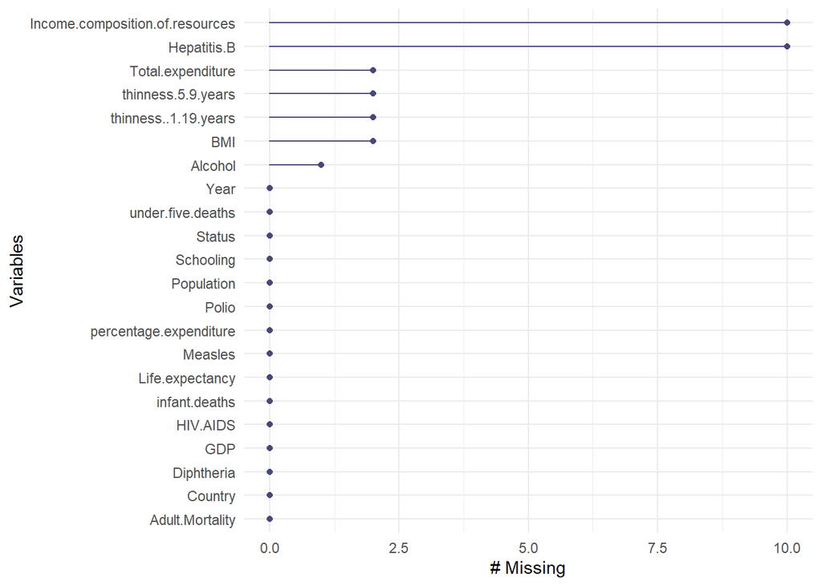

```r
gg_miss_var(Life14)
```

```r
#Can I add the avgs into the NAs without a lot of shift in data
#Life14 %>% ggplot(aes(x = Income.composition.of.resources)) + geom_histogram() #normally distributed, low effect 2% change in mean
#Life14 %>% ggplot(aes(x = Hepatitis.B)) + geom_histogram() #left-skewed, low effect 0% change in mean
#Life14 %>% ggplot(aes(x = Total.expenditure)) + geom_histogram() #normally distributed, low effect 0% change in mean
#Life14 %>% ggplot(aes(x = thinness.5.9.years)) + geom_histogram() #right-skewerd, low effect 0% change in mean
#Life14 %>% ggplot(aes(x = thinness..1.19.years)) + geom_histogram() #right-skewerd, low effect 0% change in mean
#Life14 %>% ggplot(aes(x = BMI)) + geom_histogram() #normally distributed, low effect 0% change in mean
#Life14 %>% ggplot(aes(x = Alcohol)) + geom_histogram() #right-skewerd, low effect 0% change in mean

#Replacing NAs with the mean of the column
Life14$Income.composition.of.resources[is.na(Life14$Income.composition.of.resources)] <- round(mean(Life14$Income.composition.of.resources, na.rm = TRUE))
Life14$Hepatitis.B[is.na(Life14$Hepatitis.B)] <- round(mean(Life14$Hepatitis.B, na.rm = TRUE))
Life14$Total.expenditure[is.na(Life14$Total.expenditure)] <- round(mean(Life14$Total.expenditure, na.rm = TRUE))
Life14$thinness..1.19.years[is.na(Life14$thinness..1.19.years)] <- round(mean(Life14$thinness..1.19.years, na.rm = TRUE))
Life14$thinness.5.9.years[is.na(Life14$thinness.5.9.years)] <- round(mean(Life14$thinness.5.9.years, na.rm = TRUE))
Life14$BMI[is.na(Life14$BMI)] <- round(mean(Life14$BMI, na.rm = TRUE))
Life14$Alcohol[is.na(Life14$Alcohol)] <- round(mean(Life14$Alcohol, na.rm = TRUE))
```

# Adding in some feature engineering

```r
#Factorizing things
IncomeCompFactor = cut(Life14$Income.composition.of.resources, breaks = c(0,0.4,0.7,1), labels = c("Low", "Moderate", "High"))

HepBfactor = cut(Life14$Hepatitis.B, breaks = c(0,25,50,75,100), labels = c("Deficient", "Low", "Moderate", "High"))

PercentExpendFactor = cut(Life14$percentage.expenditure, breaks = c(0,5000,15000,20000), labels = c("Low", "Moderate", "High"))

PopulationFactor = cut(Life14$Population, breaks = c(0, 3.612e+05,2.196e+07,1.294e+09), labels = c("Low", "Moderate", "High"))

GdpFactor = cut(Life14$GDP, breaks = c(0,40000,80000,120000), labels = c("Low","Moderate","High"))

SchoolFactor = cut(Life14$Schooling, breaks = c(0,12,16,21), labels = c("Low","Moderate", "High"))

# Binding them back to Life14
Life14 = cbind(Life14, HepBfactor, PercentExpendFactor, PopulationFactor, GdpFactor, SchoolFactor, IncomeCompFactor)

#Fixing some errors where for some reason it wasn't picking up these 3
Life14$PercentExpendFactor[45] = as.factor("Low")
Life14$PercentExpendFactor[149] = as.factor("Low")
Life14$SchoolFactor[149] = as.factor("Low")

#adding log variables
Life14 = Life14 %>% mutate(LHIV.AIDS = log(HIV.AIDS))
Life14 = Life14 %>% mutate(Linfant.deaths = log(infant.deaths + 1))
Life14 = Life14 %>% mutate(LUnder5Deaths = log(under.five.deaths + 1))
Life14 = Life14 %>% mutate(LThin19 = log(thinness..1.19.years + 1))
Life14 = Life14 %>% mutate(LGDP = log(GDP))
```

#Visualizing some of the data

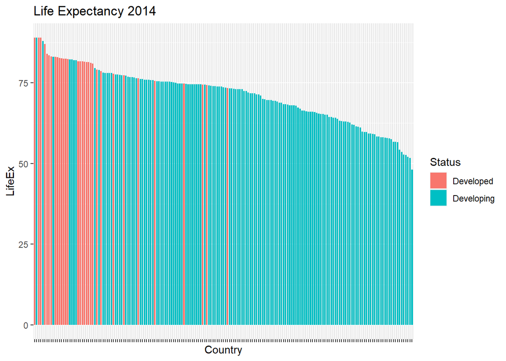

```r
# Life expectancy by Country and status -  goes well with boxplot below
Life14 %>% group_by(Country, Status) %>% summarise(LifeEx = Life.expectancy) %>%
  ggplot(aes(x = reorder(Country, -LifeEx), y = LifeEx, fill = Status)) +
  geom_col(width = 0.75, na.rm = TRUE) +
  theme(axis.text.x = element_blank()) +
  xlab("Country") +
  ggtitle("Life Expectancy 2014")
```

Boxplot of life expectancy by country status:

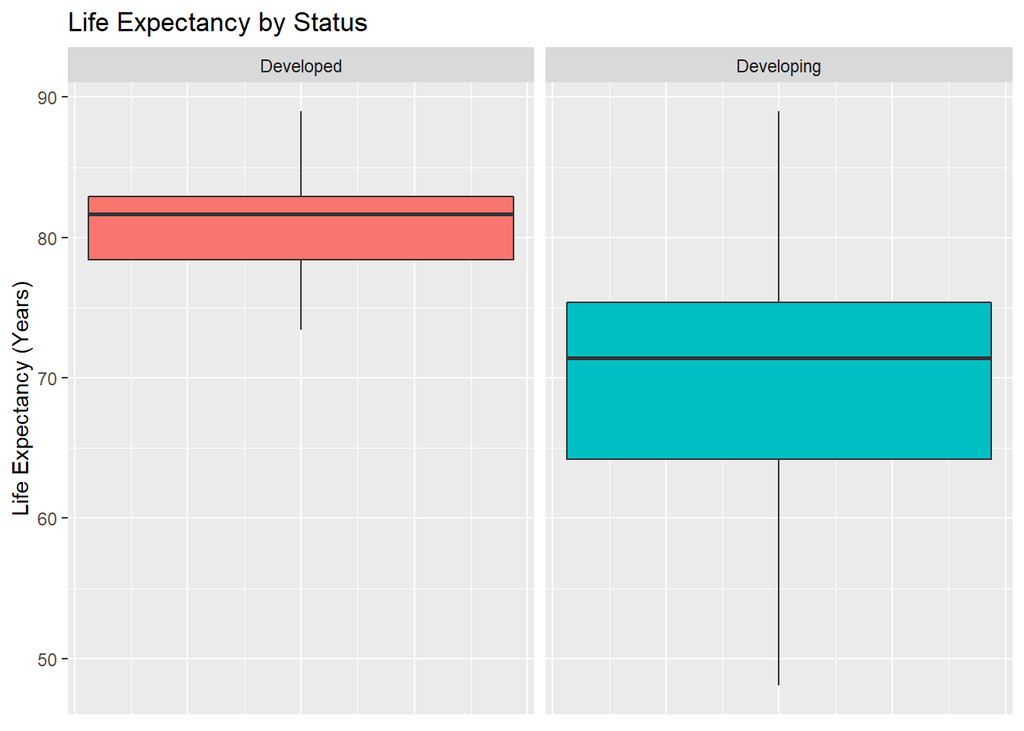

```r
Life14 %>% ggplot(aes(y = Life.expectancy)) + geom_boxplot(aes(fill = Status)) + facet_wrap(~Status) +
  ylab("Life Expectancy (Years)") + ggtitle("Life Expectancy by Status") +
  theme(axis.title.x = element_blank(), axis.text.x = element_blank(), axis.ticks.x = element_blank(), legend.position = "none")
```

Pairwise plots for selected variables:

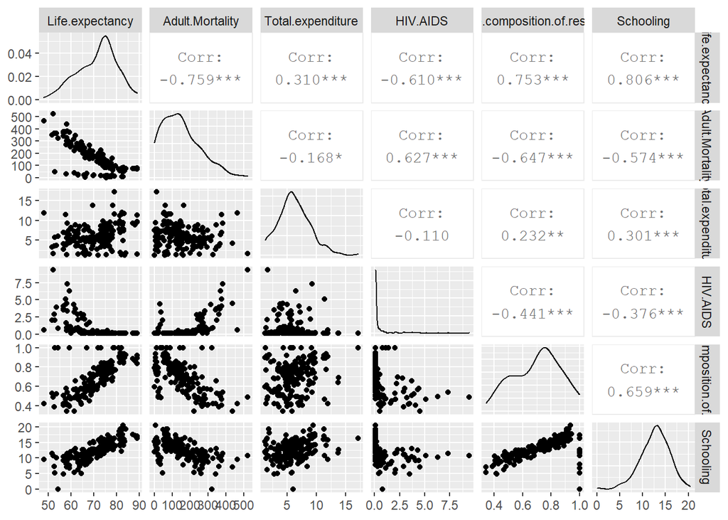

```r
df2 <- dplyr::select(Life14, c(Life.expectancy, Adult.Mortality, Total.expenditure, HIV.AIDS, Income.composition.of.resources, Schooling))
library(GGally)
ggpairs(df2)
```

Correlation between life expectancy and all the numeric independent variables:

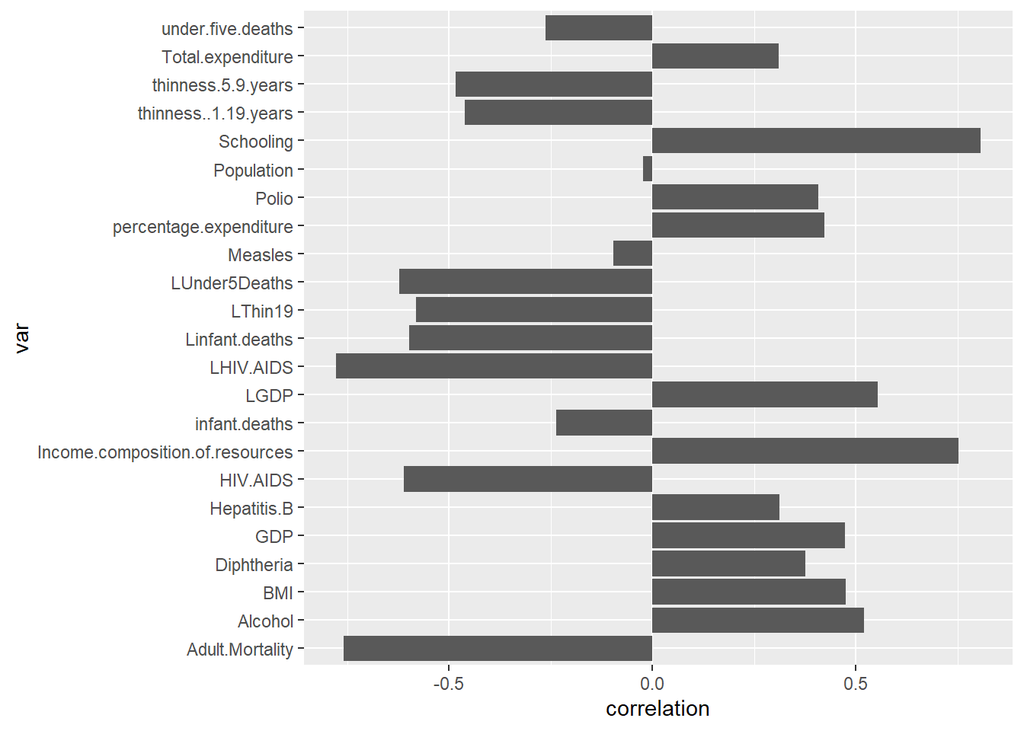

```r
# Good now
cor.xy <- cor(Life14 %>% dplyr::select(-c(Country, Year, Status,IncomeCompFactor,HepBfactor,PercentExpendFactor,PopulationFactor,GdpFactor,SchoolFactor)), use = "complete.obs")
LE.cor <- data.frame(var = rownames(cor.xy)[-1], correlation = cor.xy[-1, 1])
LE.cor %>% ggplot(aes(x = var, y = correlation)) + geom_col() + coord_flip()
```

# Checking Correlations between original variables and their logged counterparts as well as the response - we may only achieve some minor inprovements in GDP and HIV.AIDS but under 5 deaths and infant deaths have changed significantly. Also HIV.AIDS and infant deaths without the log are oddly related

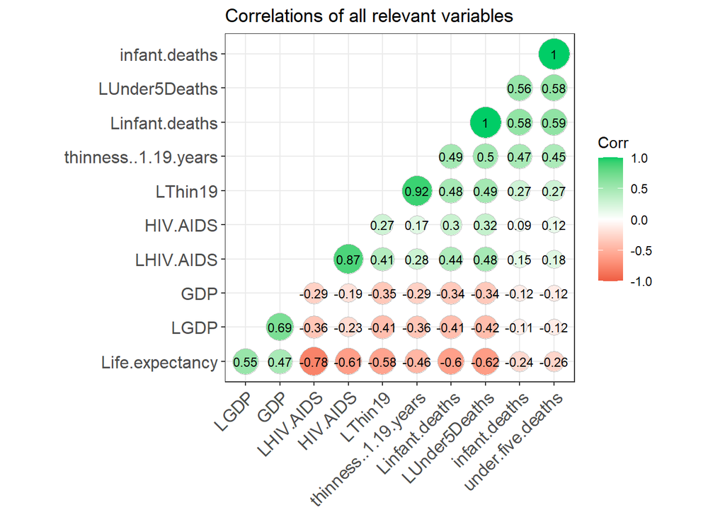

```r
corr <- Life14 %>% dplyr::select(Life.expectancy, LHIV.AIDS, Linfant.deaths, LUnder5Deaths,
                          LThin19, LGDP, GDP, infant.deaths, HIV.AIDS, under.five.deaths, thinness..1.19.years)

corr <- round(cor(corr), 2)

ggcorrplot(corr, hc.order = TRUE, type = "lower",
           lab = TRUE, lab_size = 3, method = "circle",
           colors = c("tomato2", "white", "springgreen3"),
           title = "Correlations of all relevant variables",
           ggtheme = theme_bw())
```

# Looking at Correlations for the rest of the predictors

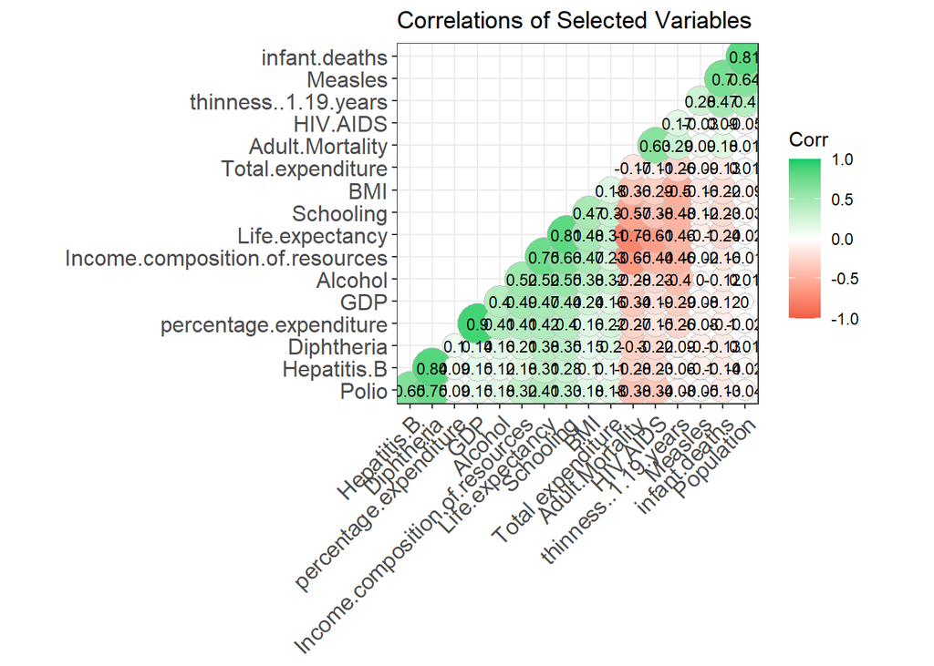

```r
exclude_factors <- c( "Country", "Year", "Status", "thinness.5.9.years", "under.five.deaths", "IncomeCompFactor",
                     "HepBfactor", "PercentExpendFactor", "SchoolFactor", "GdpFactor", "PopulationFactor",
                     "LHIV.AIDS", "Linfant.deaths", "LUnder5Deaths", "LThin19", "LGDP")

corr <- Life14 %>% dplyr::select(-all_of(exclude_factors))

corr <- round(cor(corr), 2)

ggcorrplot(corr, hc.order = TRUE, type = "lower",
           lab = TRUE, lab_size = 3, method = "circle",
           colors = c("tomato2", "white", "springgreen3"),
           title = "Correlations of Selected Variables",
           ggtheme = theme_bw())
```

Get rid of Country Name and Year

```r
exclude_factors <- c("Country", "Year")
Life14 <- Life14 %>% dplyr::select( -all_of(exclude_factors))
```

# Reasoning behind why we log-transformed some of our variables

```r
#Running full regression model
full.model <- lm(Life.expectancy~.,data=Life14)
vif(full.model)
```

```
##                                       GVIF Df GVIF^(1/(2*Df))
## Status                            2.307967  1        1.519200
## Adult.Mortality                   2.845210  1        1.686775
## infant.deaths                   454.571527  1       21.320683
## Alcohol                           2.114709  1        1.454204
## percentage.expenditure           20.983837  1        4.580812
## Hepatitis.B                      23.674974  1        4.865694
## Measles                           3.233104  1        1.798083
## BMI                               2.168702  1        1.472651
## under.five.deaths               377.194818  1       19.421504
## Polio                             3.301930  1        1.817121
## Total.expenditure                 1.418931  1        1.191189
## Diphtheria                        5.484499  1        2.341901
## HIV.AIDS                          6.047255  1        2.459117
## GDP                              18.815881  1        4.337728
## Population                        8.383426  1        2.895415
## thinness..1.19.years             34.369493  1        5.862550
## thinness.5.9.years               17.177251  1        4.144545
## Income.composition.of.resources   5.954558  1        2.440196
## Schooling                         6.112544  1        2.472356
## HepBfactor                       46.908901  3        1.899077
## PercentExpendFactor              36.068961  2        2.450662
## PopulationFactor                  3.024261  2        1.318727
## GdpFactor                        34.679217  2        2.426707
## SchoolFactor                     11.349889  2        1.835473
## IncomeCompFactor                  7.911918  2        1.677144
## LHIV.AIDS                        10.454643  1        3.233364
## Linfant.deaths                  207.621984  1       14.409094
## LUnder5Deaths                   216.997917  1       14.730849
## LThin19                          18.792663  1        4.335051
## LGDP                              3.599231  1        1.897164
```

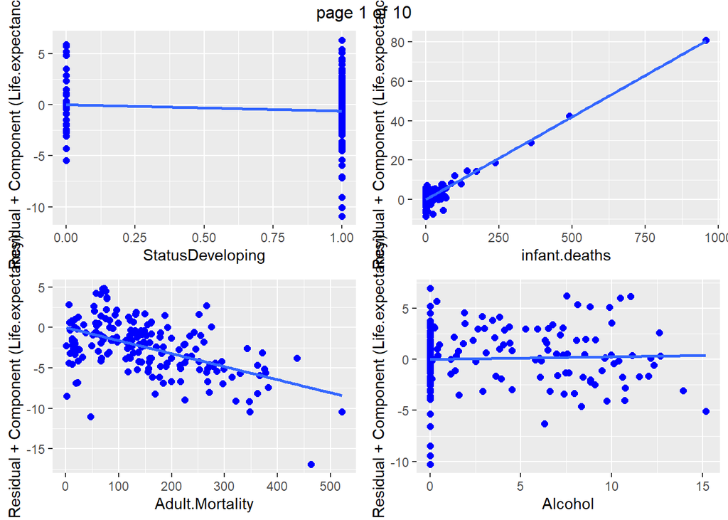

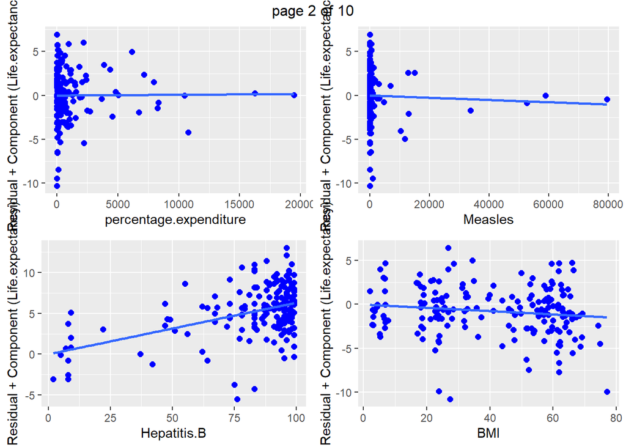

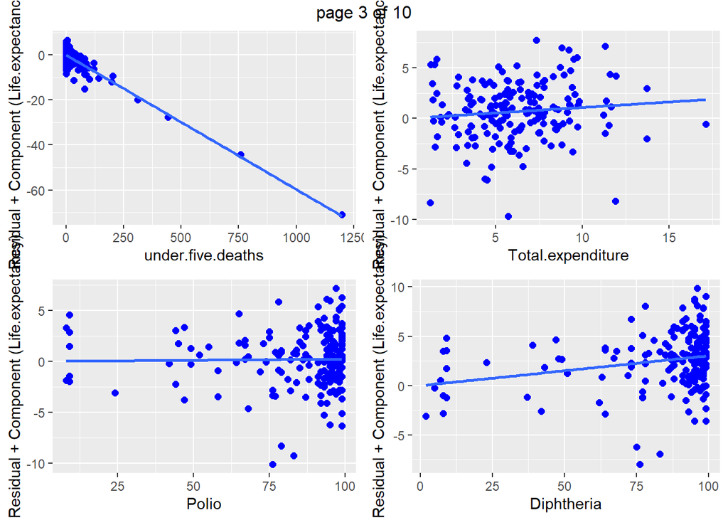

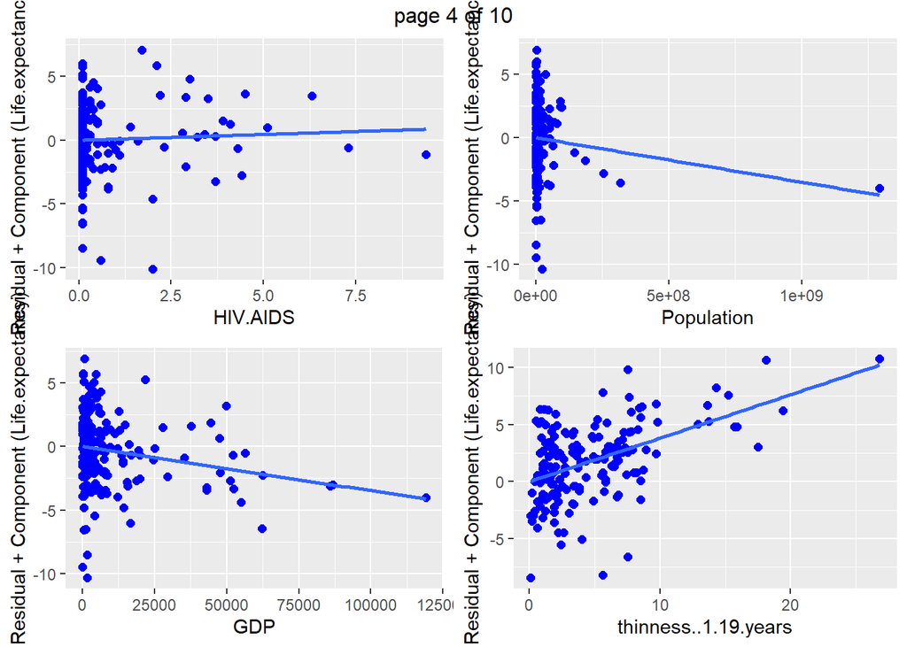

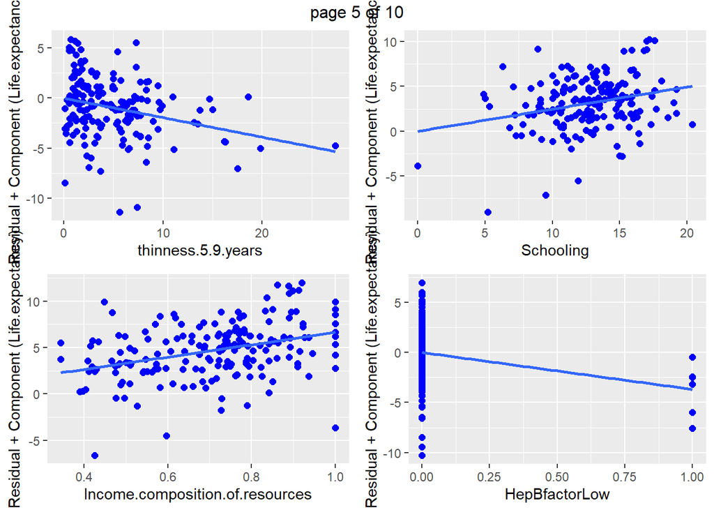

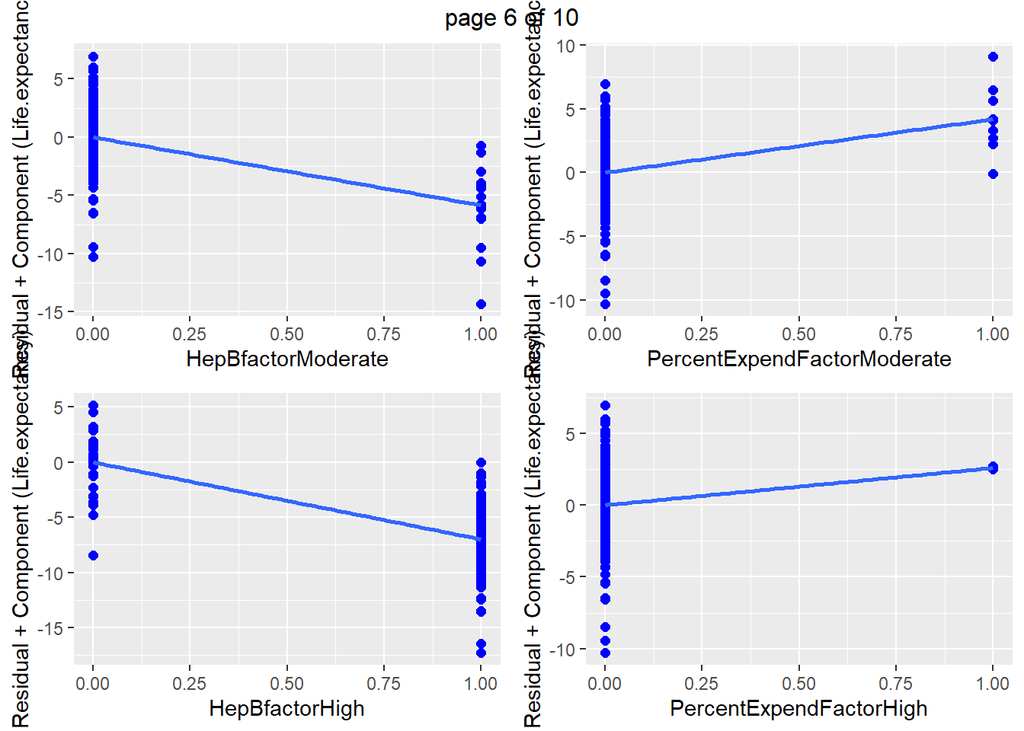

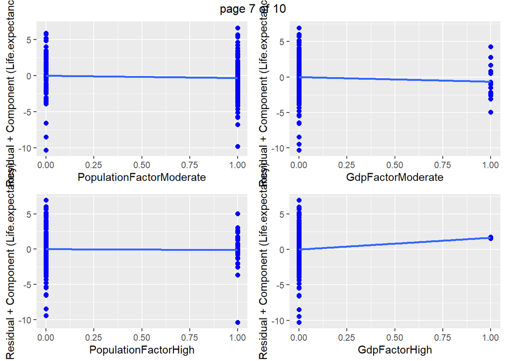

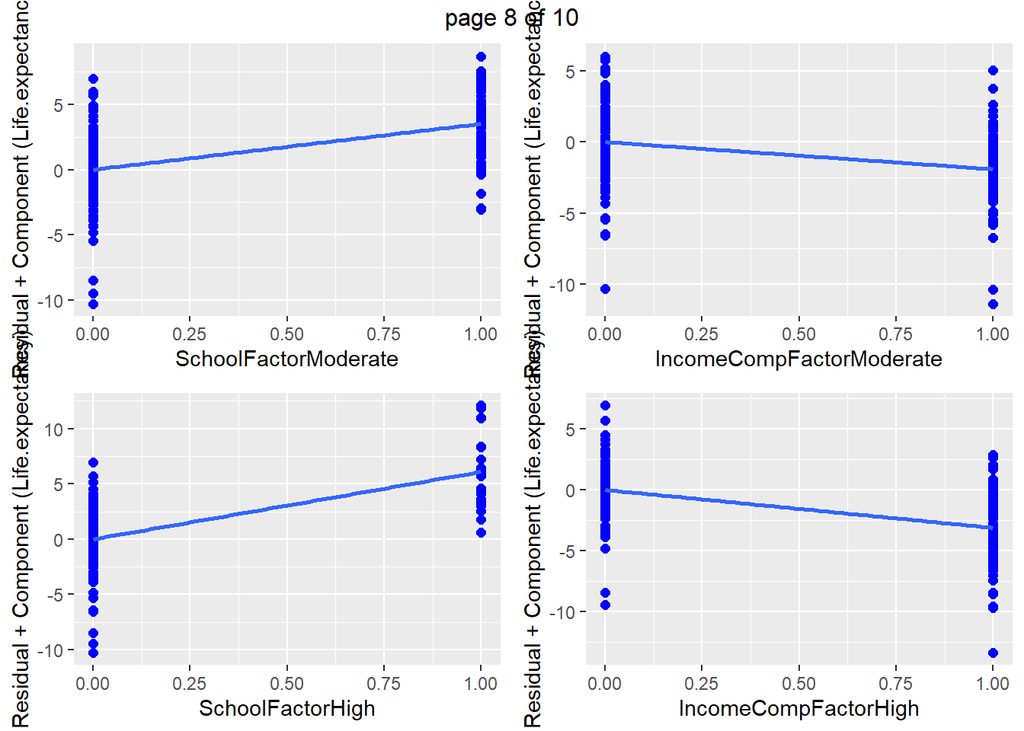

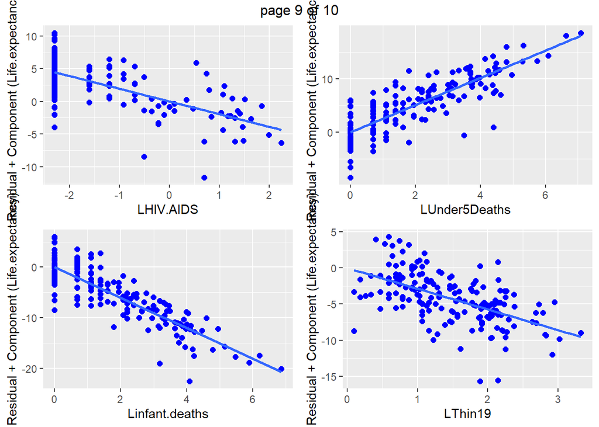

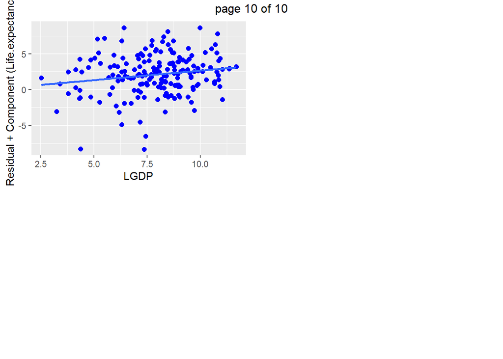

```r
ols_plot_comp_plus_resid(full.model)
```

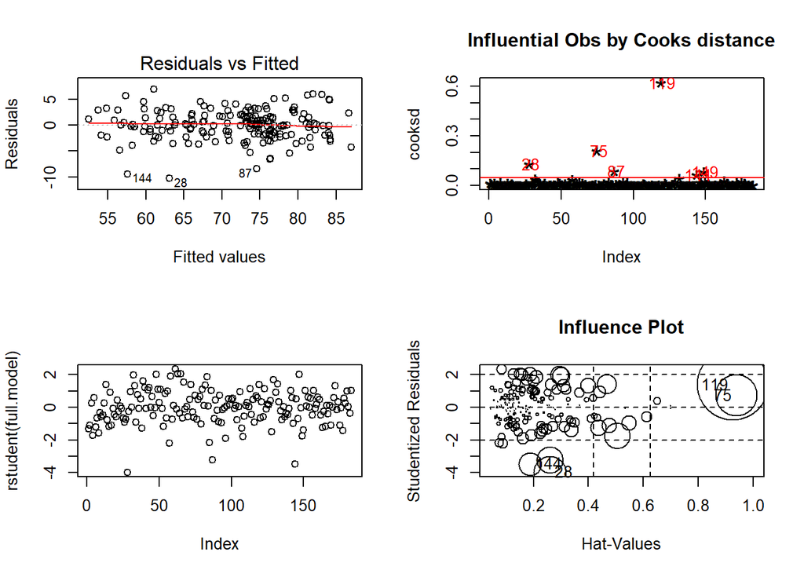

|  | StudRes | Hat | CookD |
| --- | --- | --- | --- |
| 28 | -3.9885540 | 0.2599493 | 0.13334321 |
| 75 | 0.7180947 | 0.9399004 | 0.21293315 |
| 119 | 1.3792485 | 0.9262145 | 0.62452238 |
| 130 | NaN | 1.0000000 | NaN |
| 144 | -3.4579613 | 0.1887664 | 0.06807649 |

```r
#Observe residuals and outliers
par(mfrow=c(2,2))
plot(full.model, which =1)

#Which obs are outliers according to Cooks D
cooksd <- cooks.distance(full.model)
plot(cooksd, pch="*", cex=2, main="Influential Obs by Cooks distance")  # plot cook's distance
abline(h = 4*mean(cooksd, na.rm=T), col="red")  # add cutoff line
text(x=1:length(cooksd)+1, y=cooksd, labels=ifelse(cooksd>4*mean(cooksd, na.rm=T),names(cooksd),""), col="red")
plot(rstudent(full.model))
# Influence Plot
influencePlot(full.model,  main="Influence Plot")
```

```r
#influencePlot(full.model, id.method="identify", main="Influence Plot", sub="Circle size is proportial to Cook's Distance" )
```

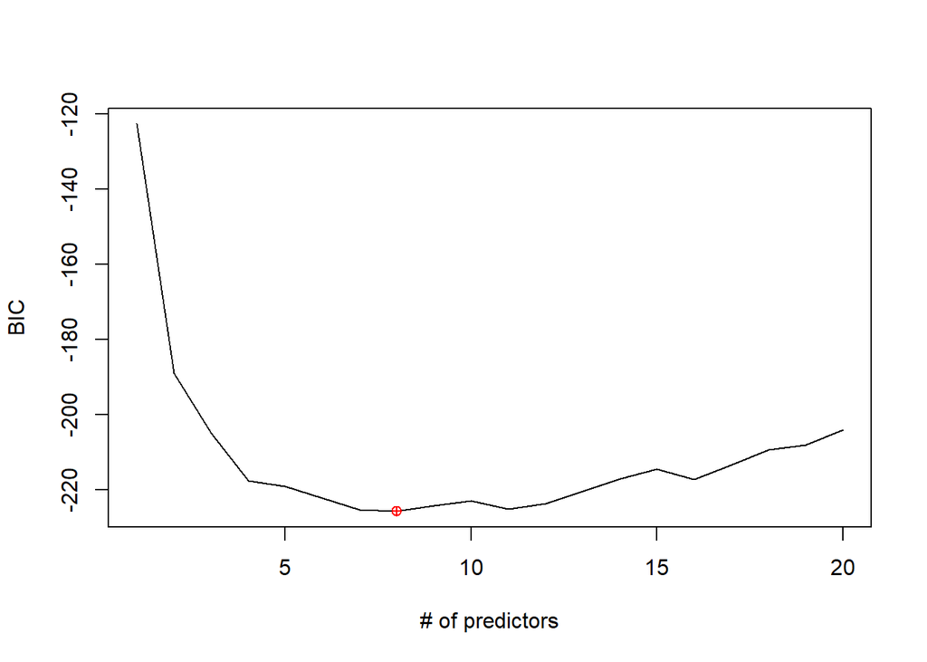

```r
# Set training and Testing Sets
#set.seed(1234)
index<-sample(1:dim(Life14)[1],128,replace=F)
train<-Life14[index,]
test<-Life14[-index,]

# Forward Selection
reg.fwd=regsubsets(Life.expectancy~.,data=train,method="forward",nvmax=20)
bics<-summary(reg.fwd)$bic
plot(1:20,bics,type="l",ylab="BIC",xlab="# of predictors")
index<-which(bics==min(bics))
points(index,bics[index],col="red",pch=10)
```

```r
print("Min Bics is:")
```

```
## [1] "Min Bics is:"
```

```r
which(bics==min(bics))
```

```
## [1] 8
```

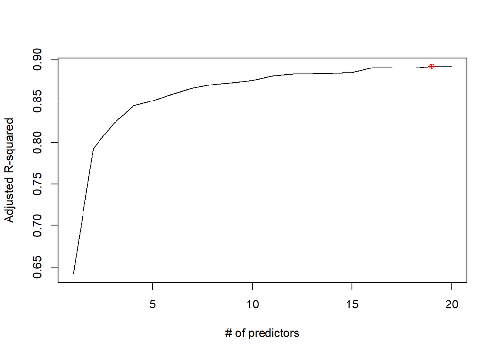

```r
# Adjr2
adjr2<-summary(reg.fwd)$adjr2
plot(1:20,adjr2,type="l",ylab="Adjusted R-squared",xlab="# of predictors")
index<-which(adjr2==max(adjr2))
points(index,adjr2[index],col="red",pch=10)
```

```r
print("Max Adj R2 is:")
```

```
## [1] "Max Adj R2 is:"
```

```r
which(adjr2==max(adjr2))
```

```
## [1] 19
```

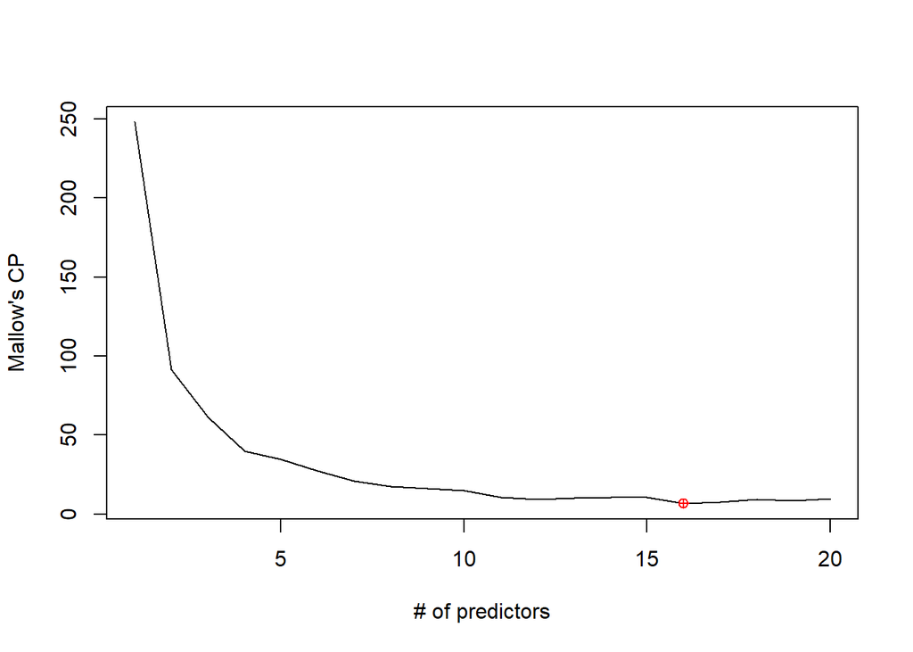

```r
MallowCP <- summary(reg.fwd)$cp
plot(1:20,MallowCP,type="l",ylab="Mallow's CP",xlab="# of predictors")
index<-which(MallowCP==min(MallowCP))
points(index,MallowCP[index],col="red",pch=10)
```

```r
print("Min Mallow CP is:")
```

```
## [1] "Min Mallow CP is:"
```

```r
which(MallowCP==min(MallowCP))
```

```
## [1] 16
```

# Used to quickly cycle though models while shuffling train/test sets

Ols step both does forward and backward selection at each step in this case based on model AIC

```r
index<-sample(1:dim(Life14)[1],128,replace=F)
train<-Life14[index,]
test<-Life14[-index,]

modelgenerator <- lm(Life.expectancy ~ . , data = train)
ols_step_both_aic(modelgenerator)
```

```
##
##
##                                        Stepwise Summary
## ---------------------------------------------------------------------------------------------
## Variable                   Method       AIC        RSS        Sum Sq      R-Sq      Adj. R-Sq
## ---------------------------------------------------------------------------------------------
## SchoolFactor              addition    786.782    3289.170    6718.225    0.67133      0.66607
## LHIV.AIDS                 addition    719.345    1912.015    8095.381    0.80894      0.80432
## Adult.Mortality           addition    701.223    1633.873    8373.523    0.83673      0.83142
## LThin19                   addition    694.989    1532.079    8475.317    0.84691      0.84063
## Diphtheria                addition    690.551    1456.921    8550.475    0.85442      0.84720
## HepBfactor                addition    686.133    1343.044    8664.352    0.86579      0.85556
## percentage.expenditure    addition    682.753    1287.764    8719.631    0.87132      0.86032
## BMI                       addition    681.973    1260.096    8747.299    0.87408      0.86214
## Total.expenditure         addition    681.250    1233.572    8773.824    0.87673      0.86387
## Schooling                 addition    680.425    1206.640    8800.756    0.87943      0.86568
## ---------------------------------------------------------------------------------------------
```

```r
# Gets significant interactions based on aic - can take a minute to run
#Interaction.modelgenerator <- lm(Life.expectancy ~ (.)^2 , data = train)
#ols_step_both_aic(Interaction.modelgenerator)
```

# Gut Model - EDA first - human variable selection - Some tech use to look at optimum number of predictors and comparison of models - income comp increases model variance

```r
index<-sample(1:dim(Life14)[1],128,replace=F)
train<-Life14[index,]
test<-Life14[-index,]

modeltest1 <- lm(Life.expectancy ~ SchoolFactor + LHIV.AIDS + Adult.Mortality + Linfant.deaths + Income.composition.of.resources + Status, data = train)


summary(modeltest1)
```

```
##
## Call:
## lm(formula = Life.expectancy ~ SchoolFactor + LHIV.AIDS + Adult.Mortality +
##     Linfant.deaths + Income.composition.of.resources + Status,
##     data = train)
##
## Residuals:
##     Min      1Q  Median      3Q     Max
## -9.0820 -1.7791 -0.1809  2.1689  7.9364
##
## Coefficients:
##                                  Estimate Std. Error t value Pr(>|t|)
## (Intercept)                     63.166434   2.541250  24.856  < 2e-16 ***
## SchoolFactorModerate             3.327645   0.878763   3.787 0.000240 ***
## SchoolFactorHigh                 7.427151   1.308398   5.677 9.73e-08 ***
## LHIV.AIDS                       -1.984215   0.348089  -5.700 8.72e-08 ***
## Adult.Mortality                 -0.019140   0.004386  -4.364 2.72e-05 ***
## Linfant.deaths                  -0.520701   0.212113  -2.455 0.015529 *
## Income.composition.of.resources 10.631591   2.863388   3.713 0.000312 ***
## StatusDeveloping                -1.010361   0.914826  -1.104 0.271616
## ---
## Signif. codes:  0 '***' 0.001 '**' 0.01 '*' 0.05 '.' 0.1 ' ' 1
##
## Residual standard error: 3.184 on 120 degrees of freedom
## Multiple R-squared:  0.8597, Adjusted R-squared:  0.8515
## F-statistic: 105.1 on 7 and 120 DF,  p-value: < 2.2e-16
```

```r
vif(modeltest1)
```

```
##                                     GVIF Df GVIF^(1/(2*Df))
## SchoolFactor                    2.813053  2        1.295074
## LHIV.AIDS                       2.152848  1        1.467259
## Adult.Mortality                 2.211428  1        1.487087
## Linfant.deaths                  1.500727  1        1.225042
## Income.composition.of.resources 2.667465  1        1.633238
## Status                          1.610120  1        1.268905
```

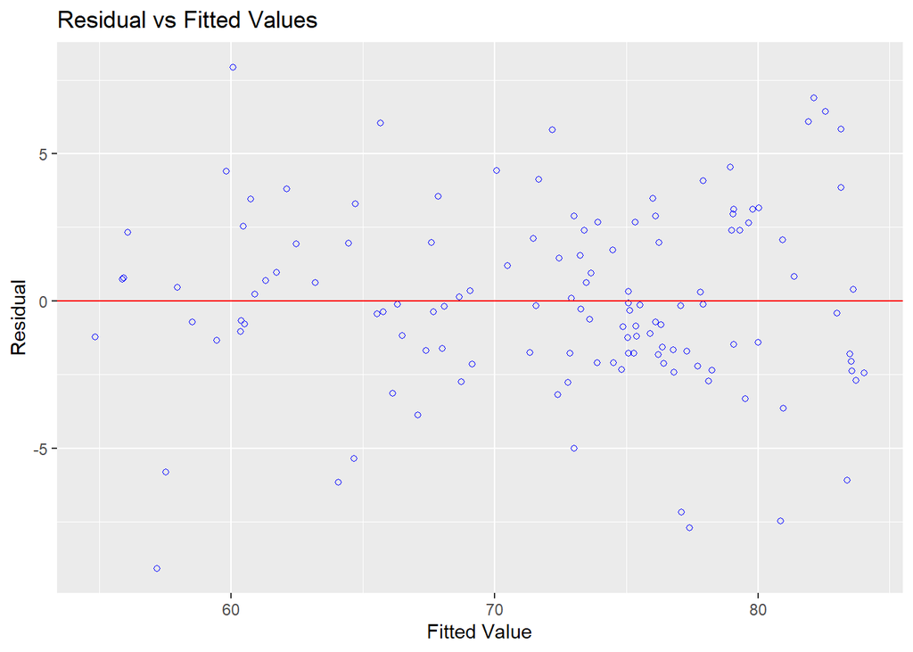

```r
ols_plot_resid_fit(modeltest1)
```

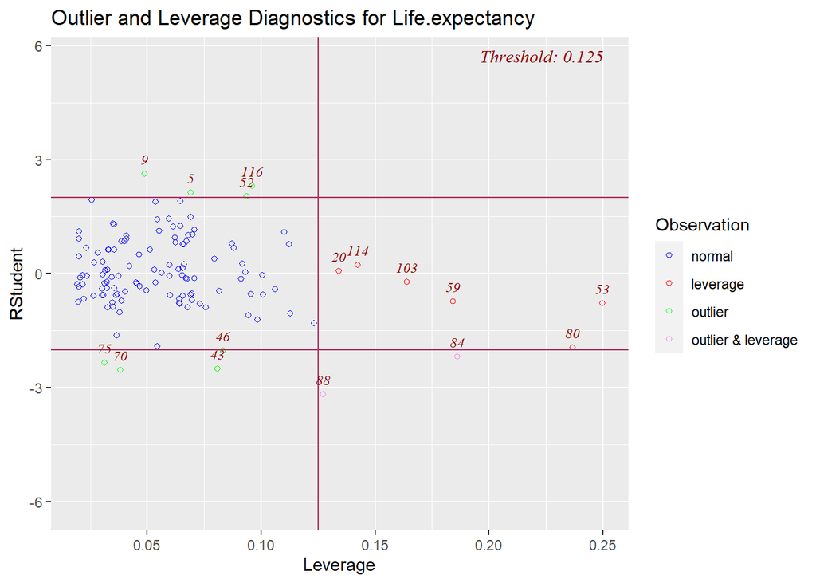

```r
ols_plot_resid_lev(modeltest1)
```

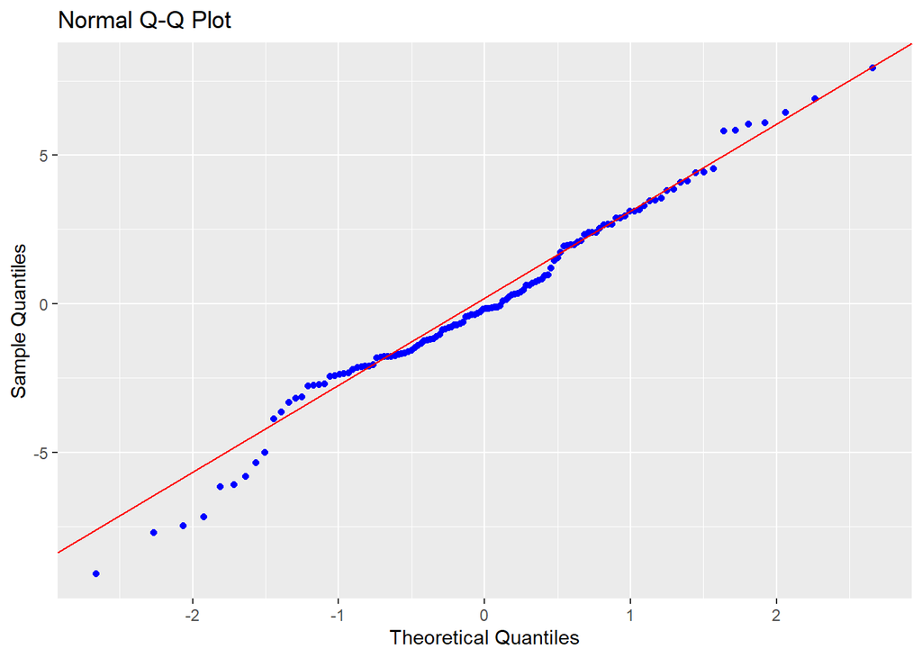

```r
ols_plot_resid_qq(modeltest1)
```

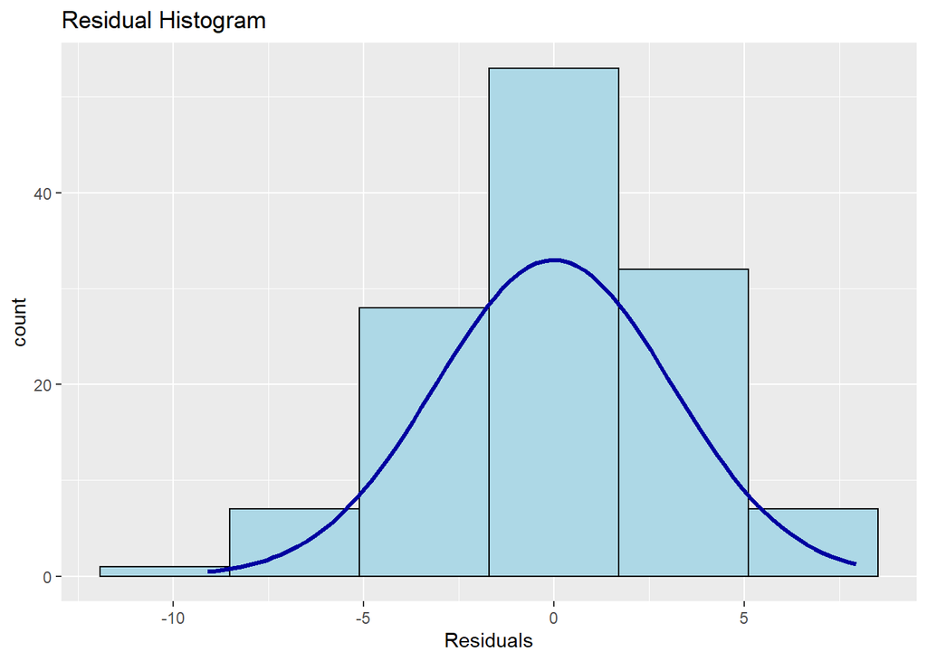

```r
ols_plot_resid_hist(modeltest1)
```

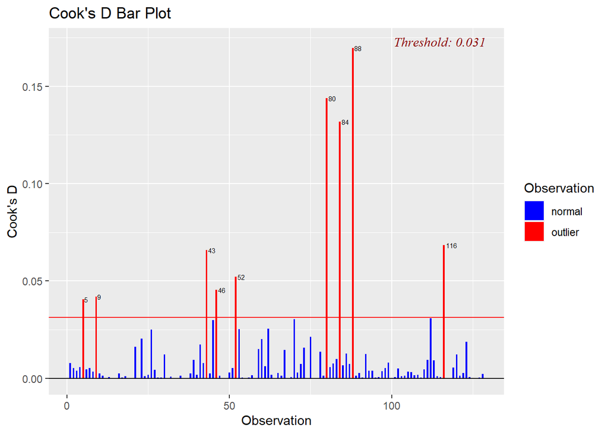

```r
ols_plot_cooksd_bar(modeltest1)
```

# complex model - Contains 4 quadratic terms and 1 interaction. Adding more interactions seems to overfit. Will occasionally show some crazy Cook’s D based on

which train/test gets selected. For a better view - run the model benchmark - easy to see over 100-500 interations

```r
modeltest2 <-  lm(Life.expectancy ~  SchoolFactor + poly(LHIV.AIDS,2) + poly(Adult.Mortality,2) + poly(under.five.deaths,2) + poly(thinness..1.19.years,2) +
                   LGDP + Income.composition.of.resources + percentage.expenditure + Income.composition.of.resources:Schooling + Status, data = train)
summary(modeltest2)
```

```
##
## Call:
## lm(formula = Life.expectancy ~ SchoolFactor + poly(LHIV.AIDS,
##     2) + poly(Adult.Mortality, 2) + poly(under.five.deaths, 2) +
##     poly(thinness..1.19.years, 2) + LGDP + Income.composition.of.resources +
##     percentage.expenditure + Income.composition.of.resources:Schooling +
##     Status, data = train)
##
## Residuals:
##     Min      1Q  Median      3Q     Max
## -6.8805 -1.5912 -0.1393  1.5621  7.6753
##
## Coefficients:
##                                             Estimate Std. Error t value
## (Intercept)                                6.222e+01  2.255e+00  27.590
## SchoolFactorModerate                       2.549e+00  1.012e+00   2.519
## SchoolFactorHigh                           4.922e+00  1.831e+00   2.687
## poly(LHIV.AIDS, 2)1                       -1.326e+01  5.028e+00  -2.637
## poly(LHIV.AIDS, 2)2                        1.166e+00  3.193e+00   0.365
## poly(Adult.Mortality, 2)1                 -2.633e+01  4.479e+00  -5.878
## poly(Adult.Mortality, 2)2                 -1.249e+01  3.354e+00  -3.725
## poly(under.five.deaths, 2)1               -1.464e+01  5.490e+00  -2.667
## poly(under.five.deaths, 2)2               -8.081e-01  3.654e+00  -0.221
## poly(thinness..1.19.years, 2)1            -1.804e+00  4.009e+00  -0.450
## poly(thinness..1.19.years, 2)2             1.803e+01  5.777e+00   3.120
## LGDP                                       1.463e-01  1.832e-01   0.799
## Income.composition.of.resources            4.696e+00  4.498e+00   1.044
## percentage.expenditure                     2.229e-04  1.195e-04   1.866
## StatusDeveloping                          -9.906e-02  8.994e-01  -0.110
## Income.composition.of.resources:Schooling  3.497e-01  3.061e-01   1.142
##                                           Pr(>|t|)
## (Intercept)                                < 2e-16 ***
## SchoolFactorModerate                      0.013167 *
## SchoolFactorHigh                          0.008303 **
## poly(LHIV.AIDS, 2)1                       0.009550 **
## poly(LHIV.AIDS, 2)2                       0.715756
## poly(Adult.Mortality, 2)1                 4.36e-08 ***
## poly(Adult.Mortality, 2)2                 0.000308 ***
## poly(under.five.deaths, 2)1               0.008795 **
## poly(under.five.deaths, 2)2               0.825388
## poly(thinness..1.19.years, 2)1            0.653564
## poly(thinness..1.19.years, 2)2            0.002297 **
## LGDP                                      0.426257
## Income.composition.of.resources           0.298740
## percentage.expenditure                    0.064674 .
## StatusDeveloping                          0.912493
## Income.composition.of.resources:Schooling 0.255716
## ---
## Signif. codes:  0 '***' 0.001 '**' 0.01 '*' 0.05 '.' 0.1 ' ' 1
##
## Residual standard error: 2.85 on 112 degrees of freedom
## Multiple R-squared:  0.8951, Adjusted R-squared:  0.8811
## F-statistic: 63.72 on 15 and 112 DF,  p-value: < 2.2e-16
```

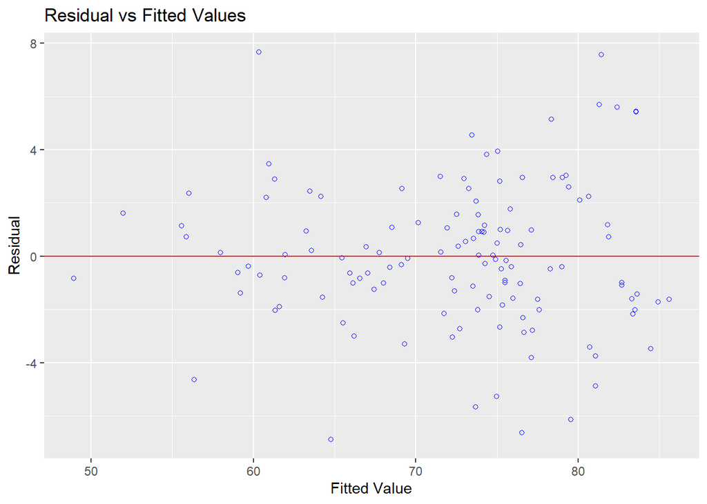

```r
ols_plot_resid_fit(modeltest2)
```

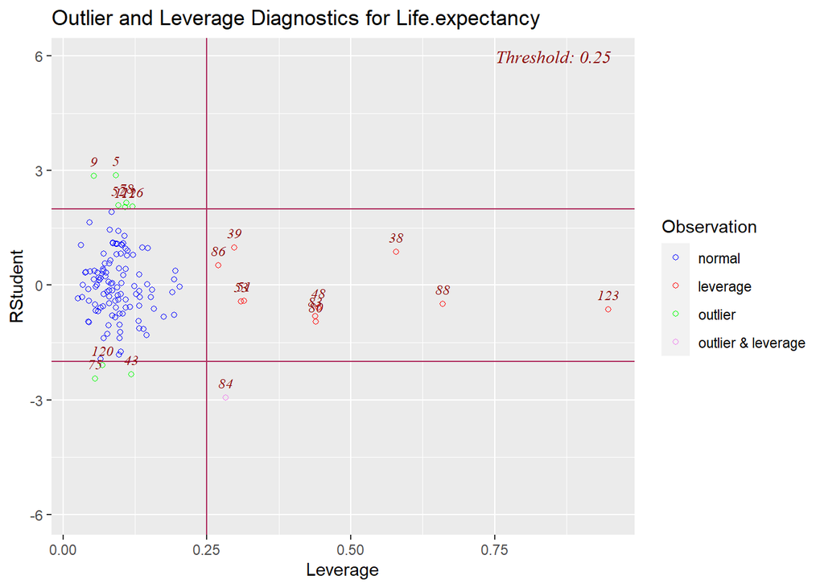

```r
ols_plot_resid_lev(modeltest2)
```

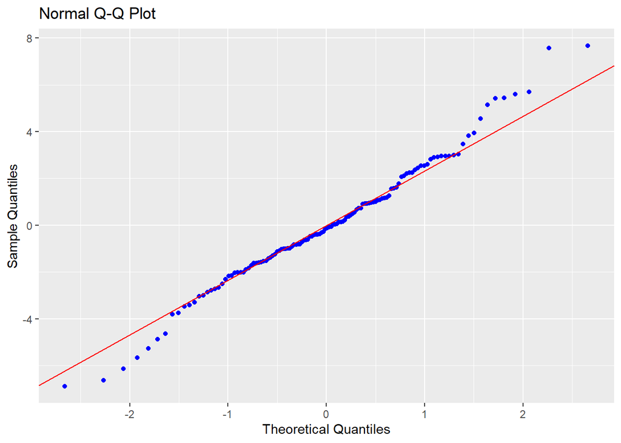

```r
ols_plot_resid_qq(modeltest2)
```

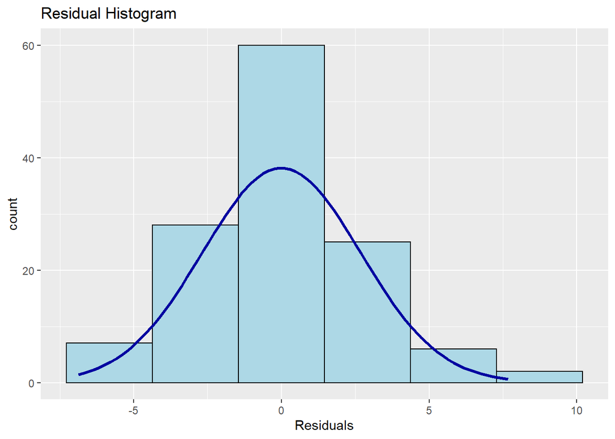

```r
ols_plot_resid_hist(modeltest2)
```

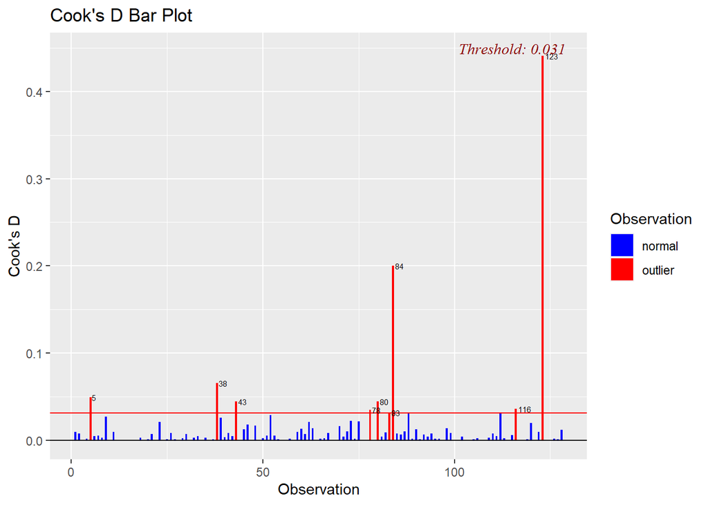

```r
ols_plot_cooksd_bar(modeltest2)
```